# Statistical Analysis of Stock Volatility

April 23, 2016

# Background and Motivation

The primary motivation of the project is to highlight the “risk” associated with Stocks by applying statistical methods to measure factors that affect the volatility of stocks such as “Market Sentiment” (“Beta”, “Standard Deviation”) and “Social Sentiment” (“Twitter chatter volume”, “Twitter sentiment score”). The fundamental reason to choose a topic in finance is partly current experience working in the industry and partly to understand the significance of “risk” being an end investor. Many of us manage different types of brokerage accounts (stock trading, 401k and IRA accounts) with no clear understanding of different risk factors associated with the returns of these accounts. The risk appetite itself differs widely with different classes of investors depending on their personal situation and other factors. Hence it is prudent for such investors to understand the risk factors associated with their individual stocks or funds. Further, the recent advances in the social media has provided a wealth of information in the form of Twitter feeds or Google trends that can further provide great insight on how the sentiment of investors can potentially affect the volatility of stocks. This research is an exploratory attempt to highlight factors that can affect stock volatility backed by appropriate statistical analysis and models.

# Project Objectives

## Concepts and Methods:

**Beta**: A quantitative measure of the volatility of a stock relative to the benchmark index, S&P 500, which is generally considered representative of the overall US securities market. Specifically, Beta is the performance the stock has experienced in the last 60 months as the S&P 500 moved 1% up or down.

A Beta of 1 indicates the stock’s price will move with the S&P 500. A Beta of less than 1 means it will be less volatile than the S&P 500. Generally, the higher the Beta, the riskier the investment. For e.g. - utilities and consumer staple stocks which are considered relatively safe have a beta of less than 0.5. On the other hand, technology and financial stocks which are considered riskier have a beta more than 1. A beta of 1.10 shows that the stock has performed 10% better than its benchmark in up markets and 10% worse in down markets, assuming all other factors remain constant. Conversely, a beta of 0.85 indicates that the stock’s return is expected to perform 15% worse than the benchmark’s return during up markets and 15% better during down markets.

A stock’s Beta is the covariance between the return on the stock (%) and the return on the benchmark (%), compared to the variance of the index. In other words, **beta is the slope of the least squares regression line fit between S&P 500 returns (benchmark as the predictor) and particular stock’s returns**.

$β = \frac{Cov(StockReturn, IndexReturn)} {Var(IndexReturn)} = \frac{σ_{xy}} {σ^2_x}$ $x = Index return, y = Stock return$

**R-Squared**: The R-squared of a stock tells investors if the beta of the stock is measured against an appropriate benchmark. Measuring the correlation of a stock’s movements to that of an index like S&P 500, R-squared describes the level of association between the stock’s volatility and market risk. It is derived by squaring the value of correlation coefficient (ρ) between stock return and index return. Its value is between -1 and +1.

$\rho_{xy} = \frac{Cov(StockReturn, IndexReturn)} {(sd(StockReturn) * sd(IndexReturn))} = \frac{σ_{xy}} {σ_x * σ_y}$ $\rho_{xy} = correlation coefficient between x and y$

**Standard Deviation**: The standard deviation is another statistical measure of a stock’s volatility. It indicates the tendency of the returns to rise or fall drastically in a short period of time. A security that is volatile is also considered higher risk because its performance may change quickly in either direction at any moment. Such volatile stocks typically have a high standard deviation.

## Data Description:

1. The first part of analysis around beta uses the public data available in [Yahoo! Finance](http://finance.yahoo.com/) and [Fidelity investment](https://research2.fidelity.com/Screener).
2. The second part of analysis around social sentiment involves scrapping social media feeds from two popular websites - [Twitter](https://twitter.com/search?q=%24AAPL&src=ctag) and [StockTwits](http://www.stocktwits.com/symbol/AAPL?q=AAPL).
3. The first dataset consists of four dataframes with historical stock prices for three chosen stocks (IBM, GS, EIX) and the S&P index (SPY) for a period of 10 years (2006 to 2016). This is extracted from the Yahoo finance and has weekly stock prices for the chosen period. Eg: [GS Historical Prices](http://finance.yahoo.com/q/hp?s=GS&a=03&b=22&c=2006&d=03&e=22&f=2016&g=w)

| Date | Open | High | Low | Close | Volume | Adj Close |
| --- | --- | --- | --- | --- | --- | --- |
| 4/18/2016 | 151.72 | 153.14 | 142.61 | 149.30 | 7887200 | 149.30 |
| 4/11/2016 | 150.26 | 152.76 | 148.58 | 151.72 | 3428700 | 151.72 |
| 4/4/2016 | 152.34 | 153.52 | 147.81 | 149.35 | 3651300 | 149.35 |
| 3/28/2016 | 147.75 | 153.10 | 147.23 | 152.52 | 4064700 | 152.52 |

4. The second dataset has the universe of US stocks (2500+) with Beta falling in the range (0 to 5.0). Fidelity stock screener provides tools to extract relevant data including stock attributes (data variables) such as Beta (1/5/10 year annualized), Sector (industry sector categorization), Total Return (5 year annualized), Standard Deviation etc

| Symbol | CompanyName | SecurityType | Sector | Annualized_Return_5Year | Annualized_SD_5Year | PE_NextYear | Annualized_Beta_5Year | TotalShares | Annualized_Beta_1Year |
| --- | --- | --- | --- | --- | --- | --- | --- | --- | --- |
| TALN | Talon International Inc | CS | Consumer Discretionary | 10.75663 | 2.21670 | 15.00000 | 0.0066691 | 92.268 | 0.7587322 |
| ED | Consolidated Edison Inc. | CS | Utilities | 9.82558 | 0.15303 | 15.28586 | 0.0173725 | 293.192 | 0.2749312 |
| IIJI | Internet Initiative Japan Inc | DR | Information Technology | 10.56512 | 0.40247 | 22.30952 | 0.0184750 | 91.905 | 1.1182022 |
| NEM | Newmont Mining Corp | CS | Materials | -19.88953 | 0.36968 | 21.13001 | 0.0252339 | 529.118 | 0.6348882 |

5. The third dataset has the twitter volume data for a basket of stocks collected between Apr 6th and Apr 30th.
6. The fourth dataset has the twitter sentiment score for a basket of stocks collected during the same period as #3.

## Assumptions:

1. The historical weekly close price is used to calculate changes in the returns of stocks for the chosen period.
2. Note that Beta can change depending on the duration of the time period, but its relation w.r.t the index returns remains the same. So specific duration of beta is not relevant as such for our analysis, but for Beta calculation, we focus on calculating the 10-year Beta (2005-2015) annualized basis.
3. Beta measures volatility of a stock relative to benchmark (S&P500) and so beta for the benchmark itself is 1 for comparison purposes.
4. Total returns (5-year Annualized) of a stock is used to evaluate the relationship b/n beta and stock returns.
5. We have chosen the exchange traded fund (SPY) as a proxy for S&P 500 index performance when comparing returns of individual stocks against benchmark.
6. We have chosen 3 stocks (IBM, GS, EIX) for our case study to understand the effect of beta on stock returns.
   1. EIX (Edison International) is an Utility company whose returns are relatively lower compared to S&P500 and so its beta is expected to be lower (<0.5).
   2. IBM (International Business Machines) is a technology company whose returns are relatively in line with S&P500 and so its beta is expected to be close to 1.0.
   3. GS (Goldman Sachs) is a financial services company whose returns are relatively higher compared to S&P500 and so its beta is expected to be higher (>1.5).

# Beta Analysis

**Load beta values for a universe of 2500+ stocks**

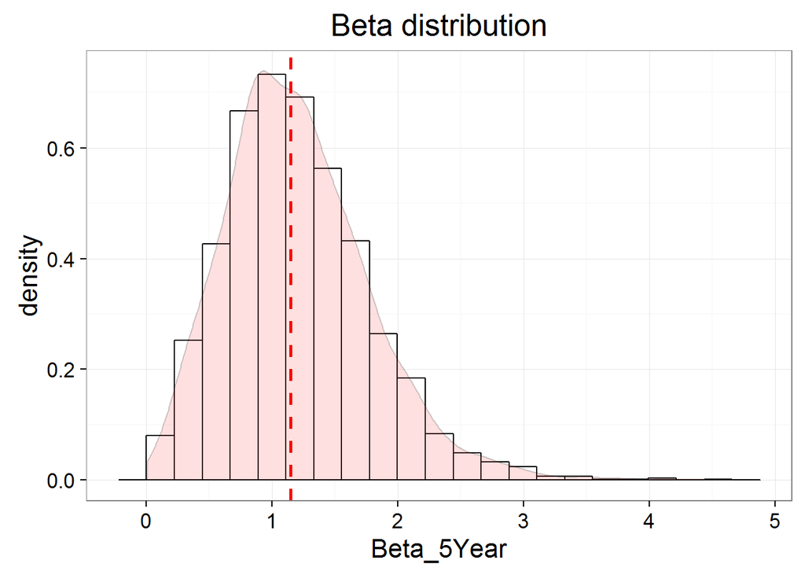

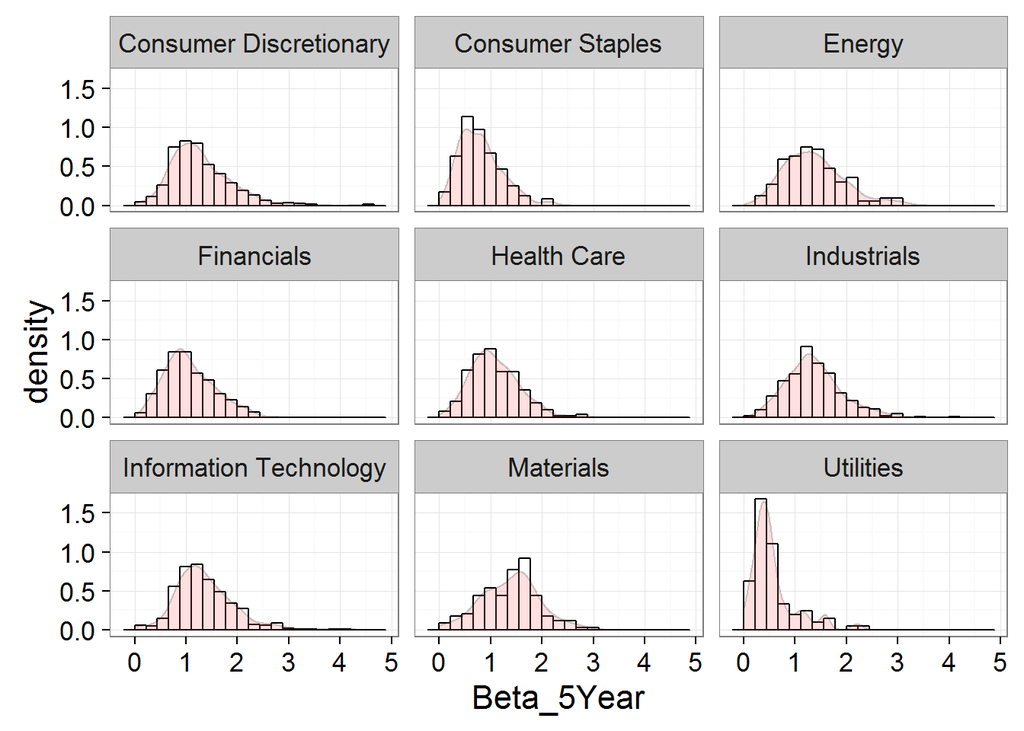

| Sector | Beta_Median | Beta_Mean | Beta_SD | Returns_Mean | Returns_SD |
| --- | --- | --- | --- | --- | --- |
| Utilities | 0.439 | 0.568 | 0.438 | 8.121 | 11.119 |
| Consumer Staples | 0.770 | 0.805 | 0.412 | 15.474 | 12.483 |
| Financials | 0.990 | 1.078 | 0.510 | 13.707 | 11.086 |
| Health Care | 1.011 | 1.084 | 0.480 | 18.709 | 16.902 |
| Consumer Discretionary | 1.194 | 1.278 | 0.583 | 12.253 | 17.247 |
| Information Technology | 1.284 | 1.361 | 0.569 | 8.020 | 16.070 |
| Energy | 1.300 | 1.365 | 0.577 | 0.000 | 17.245 |
| Industrials | 1.313 | 1.373 | 0.565 | 10.186 | 15.397 |
| Materials | 1.420 | 1.386 | 0.556 | 3.334 | 20.459 |
| ALL | 1.145 | 1.201 | 0.575 | 10.578 | 16.064 |

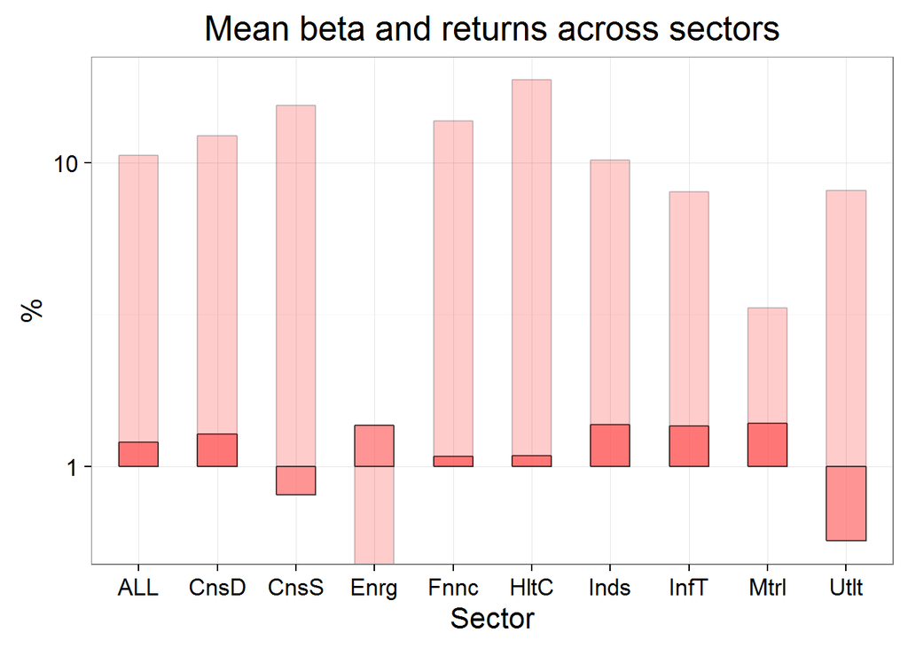

Above plots presents the higtogram and summary stats of beta (overall and classified per sector) for a universe of 2500 stocks. The shape of the distribution is roughly mounded and symmetric and hence normal distribution can reasonably fit the data. X ~ N(µ , σ2) ~ N(1.2, 0.32).

For investing purposes, Beta is further classified into categories (low/medium/high) which helps investors to choose the class of stocks they can invest depending on their risk appetite. Typically, risk-averse investors choose low beta stocks. We will basically be using three categories for our beta analysis in this paper - 0 to 0.90 (Low), 0.90 to 1.30 (Medium) and 1.30+ (High). Note that Beta can be negative as well, which means that stock returns is negatively correlated to the benchmark index returns. However, this is outside the scope of this paper.

It is clear that beta for different industry sectors are different with utilities and consumer staples having very low beta values as expected. Utilities and consumer staples tend to fluctuate less with the overall market sentiment as they are basic necessities. On the other hand, industrials and materials are cyclical in nature and their beta tends to be very high. Financials have almost perfect correlation with S&P500 with beta almost 1.

Also it is clear that returns are different for different beta. We will later see if there is a clear relation between returns and beta for a universe of 2500 stocks.

#### Compute weekly returns using historical prices - SPY and 3 chosen stocks

| Date | SPY.Close | SPY.LastClose | SPY.Returns | EIX.Close | EIX.LastClose | EIX.Returns |
| --- | --- | --- | --- | --- | --- | --- |
| 4/18/2016 | 209.24 | 207.78 | 0.703 | 71.10 | 75.85 | -6.262 |
| 4/11/2016 | 207.78 | 204.50 | 1.604 | 75.85 | 76.04 | -0.250 |

| Date | IBM.Close | IBM.LastClose | IBM.Returns | GS.Close | GS.LastClose | GS.Returns |
| --- | --- | --- | --- | --- | --- | --- |
| 4/18/2016 | 149.30 | 151.72 | -1.595 | 166.75 | 158.52 | 5.192 |
| 4/11/2016 | 151.72 | 149.35 | 1.587 | 158.52 | 150.28 | 5.483 |

[output not shown]

### Beta Computation: Case Study of 3 stocks

The summary of correlation and regression model coefficients for the selected stocks against SPY is presented below. Note that, from the definition of Beta, the slope of the best fit line provides an estimate of its value. A detailed analysis of how beta is estimated for each stock follows.

[output not shown]

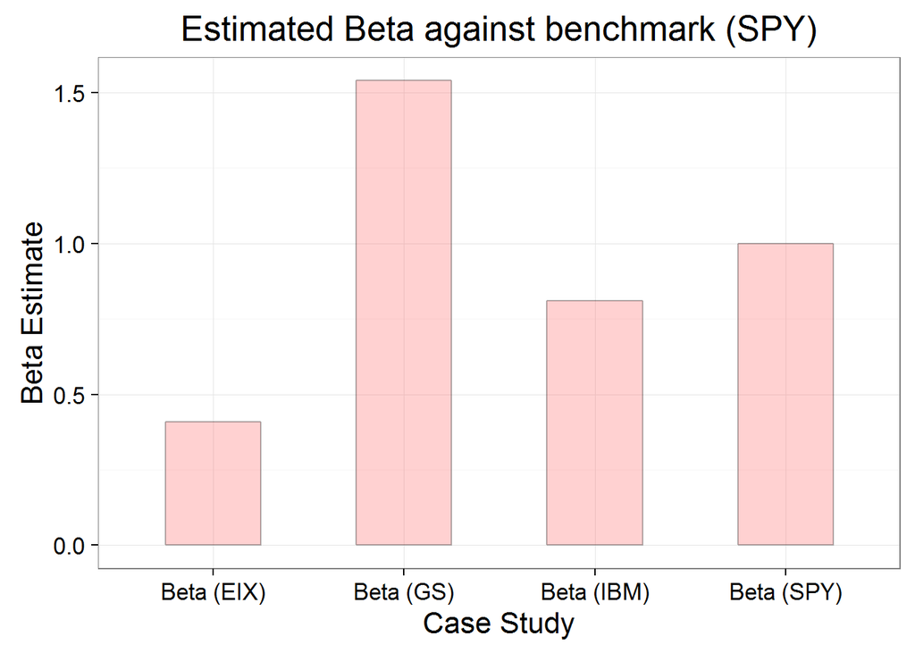

### Analysis for a low-beta stock (EIX)

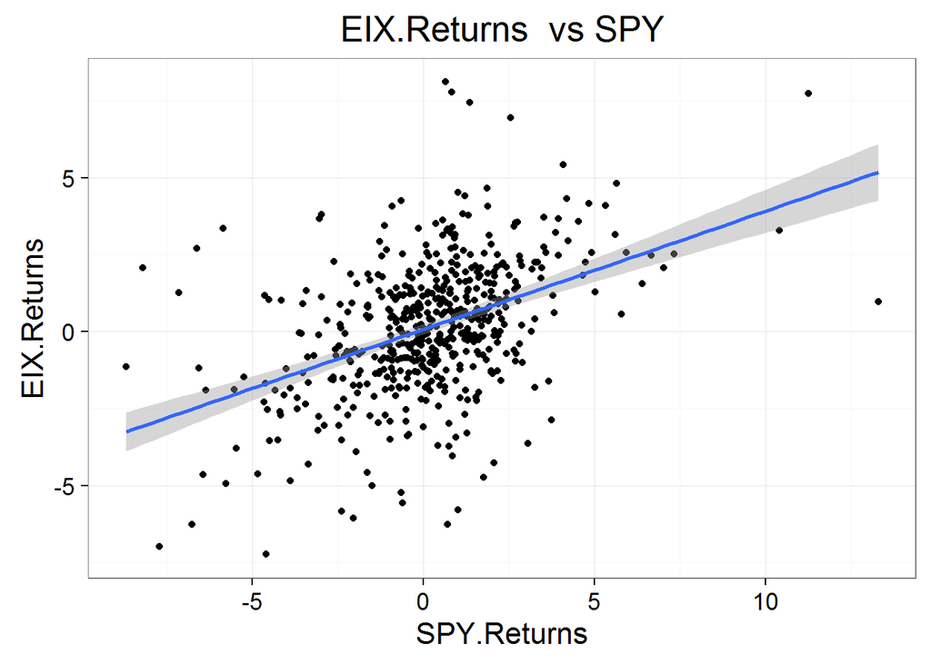

### Analysis for a medium-beta stock (IBM)

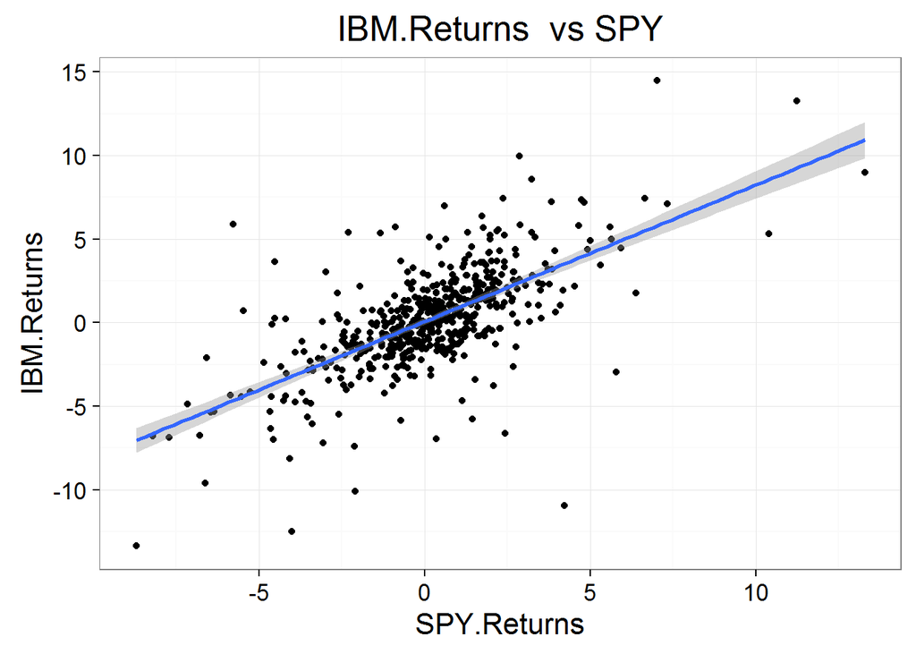

### Analysis for a high-beta stock (GS)

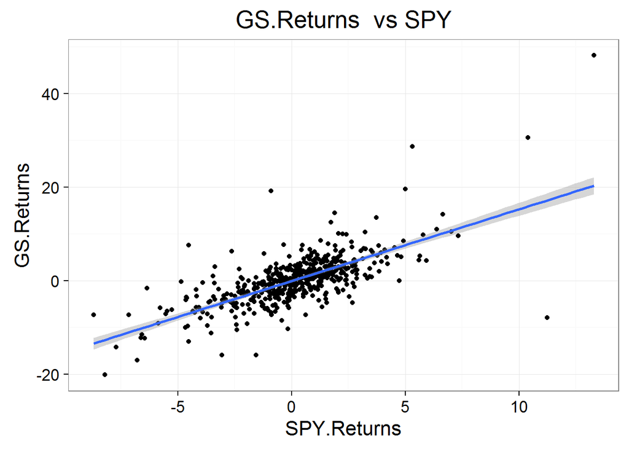

### Regression between beta and stock returns

Having computed Beta for three stocks with widely differing returns, we will now generalize the relationship between Beta and total returns (both 5-year annualized) by fitting a linear regression model for the chosen universe of 2500+ stocks. In order to fit a better model, we will exclude outlier stocks with returns in excess of 80%. Below scatterplot shows the results with the beta as the predictor.

| term | estimate | std.error | statistic | p.value | conf.low | conf.high | cor | r.squared(%) | beta_range |
| --- | --- | --- | --- | --- | --- | --- | --- | --- | --- |
| Slope estimate for beta (0.0 to 4.5) | -5.476 | 0.541 | -10.123 | 0 | -6.536 | -4.415 | -0.196 | 3.837 | 0.0 to 4.5 |

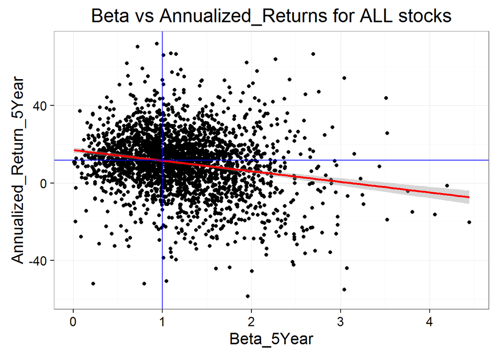

1. The slope came out as -5.48. This means that for every 1-unit increase in beta (risk factor in the underlying stock), the total return of the stock would actually reduce by 5.48% on an annualized basis. At first, it appears counter-intuitive as one expects better performance with additional risk. But this is actually true with only handful of selected stocks. For the majority, stocks with very high beta actually perform worse over time.
2. When Beta=1, the stock performance should be in line with the benchmark (S&P 500). This is highlighted in the scatterplot with average stock return = 11.68%.
3. Assuming Rs represents the expected return on the stock (y-axis) and Rb represents the expected return of the benchmark (S&P500), this model can be generalized as follows - $R_s = R_f + R_b*β$ where β = Beta and Rf = intercept showing the stock return when there is no risk.
4. Fitting the regression coefficients, we get the equation - $R_s = 17.16 - 5.48*β$ where β<=4.5

### Trend estimation using smoothing

R-squared value for the fit came at only 3.8% which is rather a poor fit. Instead of blindly interpretting the regression results, we would now attempt to use smoothing to see if a different trend can explain the relationship better.

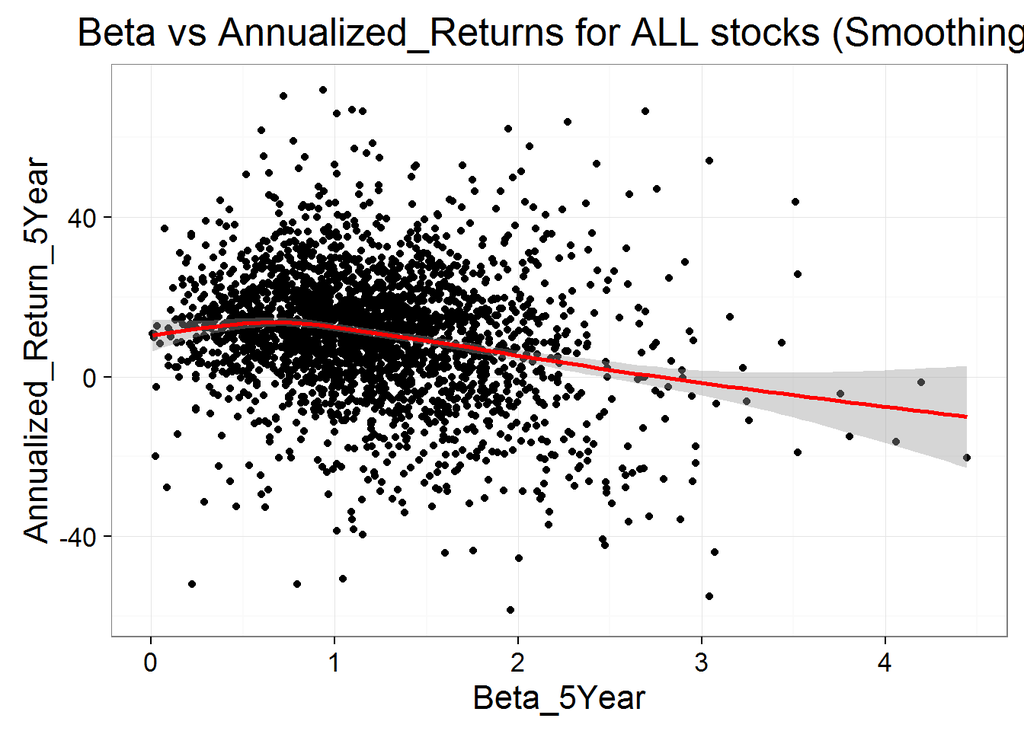

The above plot clearly shows that returns are actually trending upwards as the beta increases upto certain threshold. This trend appears to be true with in the universe of low beta stocks (< 0.8). After that threshold, returns actually goes lower with much higher beta values.

### Regression between low beta stocks and returns

Low beta stocks are less volatile and their returns are expected to be more predictable when compared to the benchmark (S&P500) returns. We would like to now see if above relationship of lower returns with increasing beta holds good within the universe of low beta stocks. Basically, we will repeat above analysis for stocks having beta within the 1st quartile. As done before, we will exclude outlier stocks with returns in excess of 80%.

```
## [1] "Beta summary stats"
```

```
##     Min.  1st Qu.   Median     Mean  3rd Qu.     Max.
## 0.006669 0.807000 1.145000 1.201000 1.538000 4.444000
```

```
## [1] "Slope estimate with beta as predictor"
```

| term | estimate | std.error | statistic | p.value | conf.low | conf.high | cor | r.squared(%) | beta_range |
| --- | --- | --- | --- | --- | --- | --- | --- | --- | --- |
| Slope estimate for beta (0.0 to 4.5) | -5.476 | 0.541 | -10.123 | 0.000 | -6.536 | -4.415 | -0.196 | 3.837 | 0.0 to 4.5 |
| Slope estimate for beta (0.0 to 0.8) | 6.442 | 2.735 | 2.356 | 0.019 | 1.072 | 11.811 | 0.093 | 0.860 | 0.0 to 0.8 |

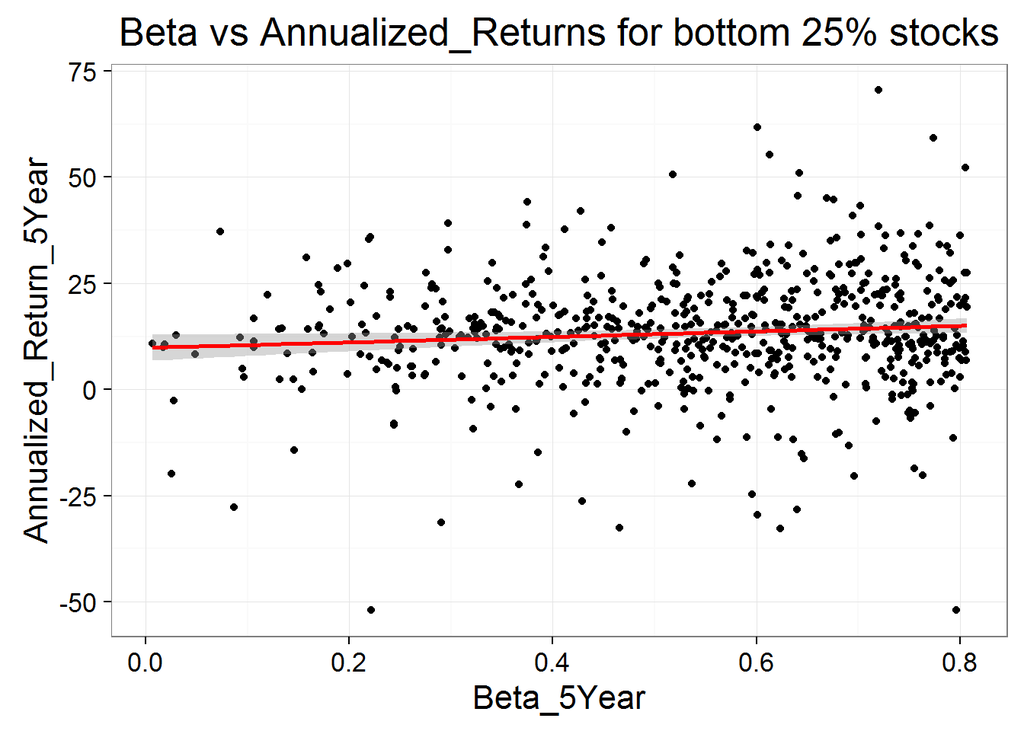

The results appears more interesting and are in agreeement with the smoother trend we have seen earlier. The returns within the universe of low beta stocks are actually better with increasing beta. The slope of the best fit regression line came as 6.44 which means that for every 0.1 unit increase in beta (range: 0.0 to 0.8), the total return of the stock would actually increase by about 0.64% on an annualised basis. This appears intuitive with expectations of higher returns with higher risk (beta) stocks, but however this trend of higher returns doesn’t hold good with much higher beta stocks actually returning lower returns over time. This tells us there is a threshold with beta values after which higher risk actually translates lower returns.

Fitting the regression coefficients, we get the equation - $R_s = 9.83 + 6.44*β$ where β <= 0.8

### Analysis of a basket of low-volatility stocks vs high-volatility stocks

From the regression, it appears very well that very high beta stocks actually perform worse compared to lower beta stocks over time. We would want to see if this infact true by running a simulation. In particular, we want to see if a portfolio of low-volatility stocks earn returns better than a portfolio of high-volatility stocks. We will perform this analysis using Monte Carlo simulation by dividing the universe of stocks (2500+) into quartiles (4 buckets). We will analyse the returns of lowest (bottom 25%) and highest (top 25%) beta stocks by randomly sampling 100 stocks from each bucket repeatedly to calculate mean returns.

**MonteCarlo simulation**

| Classification | Min_Beta | Max_Beta | Mean_Returns | SE_Returns | CI_low (95%) | CI_high (95%) |
| --- | --- | --- | --- | --- | --- | --- |
| Low Beta Stocks (bottom 25%) | 0.007 | 0.807 | 13.406 | 1.242 | 10.97 | 15.84 |
| High Beta Stocks (top 25%) | 1.538 | 4.444 | 5.467 | 1.718 | 2.10 | 8.83 |

From above results, it appears very well that Monte Carlo simulation is in agreement with the regression results above. On an average, the mean returns of low beta stocks is much higher when compared to very high beta stocks.

# Conclusion

The detailed statistical analysis is an attempt to present the Beta as a measure of stock volatility (or risk). The exploratory data analysis of “beta” is shown be to normal and further the case study of 3 very distinct stocks demonstrates that the volatility of a stock can be explained to some extent using the volatility of the benchmark index (S&P500). The next study of beta demonstrates there is a trend between beta and the stock returns analysed for a universe of 2500 stocks. The returns within the universe of low beta stocks are actually better with increasing beta (< 0.8). however, this trend doesn’t hold good with stocks having much higher beta (> 1.0) where returns are actually lower over time (5 year period). This was also confirmed with the Monte Carlo simulation done comparing the returns of low-beta stocks against the high-beta ones.